# Risk Factor Analysis

## Outcome Variable

**Outcome Variable:** sstunted

## Predictor Variables

**Intervention Variable:** mhtcm

**Adjustment Set:**

- arm
- W_mage
- meducyrs
- feducyrs
- hhwealth_quart
- W_nrooms
- impfloor
- impsan
- safeh20
- delta_W_mage
- delta_meducyrs
- delta_feducyrs
- delta_hhwealth_quart
- delta_W_nrooms
- delta_impfloor
- delta_impsan
- delta_safeh20

## Stratifying Variables

The analysis was stratified on these variable(s):

- agecat
- studyid
- country

## Data Summary

| agecat | studyid | country | mhtcm | sstunted | n_cell | n |
| --- | --- | --- | --- | --- | --- | --- |
| Birth | ki0047075b-MAL-ED | BANGLADESH | >=155 cm | 0 | 24 | 246 |
| Birth | ki0047075b-MAL-ED | BANGLADESH | >=155 cm | 1 | 1 | 246 |
| Birth | ki0047075b-MAL-ED | BANGLADESH | <151 cm | 0 | 150 | 246 |
| Birth | ki0047075b-MAL-ED | BANGLADESH | <151 cm | 1 | 6 | 246 |
| Birth | ki0047075b-MAL-ED | BANGLADESH | [151-155) cm | 0 | 65 | 246 |
| Birth | ki0047075b-MAL-ED | BANGLADESH | [151-155) cm | 1 | 0 | 246 |
| Birth | ki0047075b-MAL-ED | BRAZIL | >=155 cm | 0 | 104 | 184 |
| Birth | ki0047075b-MAL-ED | BRAZIL | >=155 cm | 1 | 3 | 184 |
| Birth | ki0047075b-MAL-ED | BRAZIL | <151 cm | 0 | 46 | 184 |
| Birth | ki0047075b-MAL-ED | BRAZIL | <151 cm | 1 | 3 | 184 |
| Birth | ki0047075b-MAL-ED | BRAZIL | [151-155) cm | 0 | 26 | 184 |
| Birth | ki0047075b-MAL-ED | BRAZIL | [151-155) cm | 1 | 2 | 184 |
| Birth | ki0047075b-MAL-ED | INDIA | >=155 cm | 0 | 45 | 198 |
| Birth | ki0047075b-MAL-ED | INDIA | >=155 cm | 1 | 1 | 198 |
| Birth | ki0047075b-MAL-ED | INDIA | <151 cm | 0 | 91 | 198 |
| Birth | ki0047075b-MAL-ED | INDIA | <151 cm | 1 | 4 | 198 |
| Birth | ki0047075b-MAL-ED | INDIA | [151-155) cm | 0 | 55 | 198 |
| Birth | ki0047075b-MAL-ED | INDIA | [151-155) cm | 1 | 2 | 198 |
| Birth | ki0047075b-MAL-ED | NEPAL | >=155 cm | 0 | 27 | 172 |
| Birth | ki0047075b-MAL-ED | NEPAL | >=155 cm | 1 | 0 | 172 |
| Birth | ki0047075b-MAL-ED | NEPAL | <151 cm | 0 | 93 | 172 |
| Birth | ki0047075b-MAL-ED | NEPAL | <151 cm | 1 | 3 | 172 |
| Birth | ki0047075b-MAL-ED | NEPAL | [151-155) cm | 0 | 46 | 172 |
| Birth | ki0047075b-MAL-ED | NEPAL | [151-155) cm | 1 | 3 | 172 |
| Birth | ki0047075b-MAL-ED | PERU | >=155 cm | 0 | 57 | 276 |
| Birth | ki0047075b-MAL-ED | PERU | >=155 cm | 1 | 1 | 276 |
| Birth | ki0047075b-MAL-ED | PERU | <151 cm | 0 | 155 | 276 |
| Birth | ki0047075b-MAL-ED | PERU | <151 cm | 1 | 6 | 276 |
| Birth | ki0047075b-MAL-ED | PERU | [151-155) cm | 0 | 57 | 276 |
| Birth | ki0047075b-MAL-ED | PERU | [151-155) cm | 1 | 0 | 276 |

[output cut: 318 more lines]

The following strata were considered:

- agecat: 24 months, studyid: ki0047075b-MAL-ED, country: BANGLADESH
- agecat: 24 months, studyid: ki0047075b-MAL-ED, country: BRAZIL
- agecat: 24 months, studyid: ki0047075b-MAL-ED, country: INDIA
- agecat: 24 months, studyid: ki0047075b-MAL-ED, country: NEPAL
- agecat: 24 months, studyid: ki0047075b-MAL-ED, country: PERU
- agecat: 24 months, studyid: ki0047075b-MAL-ED, country: SOUTH AFRICA
- agecat: 24 months, studyid: ki0047075b-MAL-ED, country: TANZANIA, UNITED REPUBLIC OF
- agecat: 24 months, studyid: ki1017093-NIH-Birth, country: BANGLADESH
- agecat: 24 months, studyid: ki1017093b-PROVIDE, country: BANGLADESH
- agecat: 24 months, studyid: ki1017093c-NIH-Crypto, country: BANGLADESH
- agecat: 24 months, studyid: ki1066203-TanzaniaChild2, country: TANZANIA, UNITED REPUBLIC OF
- agecat: 24 months, studyid: ki1101329-Keneba, country: GAMBIA
- agecat: 24 months, studyid: ki1119695-PROBIT, country: BELARUS
- agecat: 24 months, studyid: ki1126311-ZVITAMBO, country: ZIMBABWE
- agecat: 24 months, studyid: ki1135781-COHORTS, country: GUATEMALA
- agecat: 24 months, studyid: ki1135781-COHORTS, country: INDIA
- agecat: 24 months, studyid: ki1135781-COHORTS, country: PHILIPPINES
- agecat: 24 months, studyid: ki1148112-LCNI-5, country: MALAWI
- agecat: 24 months, studyid: kiGH5241-JiVitA-3, country: BANGLADESH
- agecat: 6 months, studyid: ki0047075b-MAL-ED, country: BANGLADESH
- agecat: 6 months, studyid: ki0047075b-MAL-ED, country: BRAZIL
- agecat: 6 months, studyid: ki0047075b-MAL-ED, country: INDIA
- agecat: 6 months, studyid: ki0047075b-MAL-ED, country: NEPAL
- agecat: 6 months, studyid: ki0047075b-MAL-ED, country: PERU
- agecat: 6 months, studyid: ki0047075b-MAL-ED, country: SOUTH AFRICA
- agecat: 6 months, studyid: ki0047075b-MAL-ED, country: TANZANIA, UNITED REPUBLIC OF
- agecat: 6 months, studyid: ki1000304b-SAS-CompFeed, country: INDIA
- agecat: 6 months, studyid: ki1000304b-SAS-FoodSuppl, country: INDIA
- agecat: 6 months, studyid: ki1017093-NIH-Birth, country: BANGLADESH
- agecat: 6 months, studyid: ki1017093b-PROVIDE, country: BANGLADESH
- agecat: 6 months, studyid: ki1017093c-NIH-Crypto, country: BANGLADESH
- agecat: 6 months, studyid: ki1066203-TanzaniaChild2, country: TANZANIA, UNITED REPUBLIC OF
- agecat: 6 months, studyid: ki1101329-Keneba, country: GAMBIA
- agecat: 6 months, studyid: ki1112895-Guatemala BSC, country: GUATEMALA
- agecat: 6 months, studyid: ki1119695-PROBIT, country: BELARUS
- agecat: 6 months, studyid: ki1126311-ZVITAMBO, country: ZIMBABWE
- agecat: 6 months, studyid: ki1135781-COHORTS, country: GUATEMALA
- agecat: 6 months, studyid: ki1135781-COHORTS, country: INDIA
- agecat: 6 months, studyid: ki1135781-COHORTS, country: PHILIPPINES
- agecat: 6 months, studyid: ki1148112-LCNI-5, country: MALAWI
- agecat: 6 months, studyid: kiGH5241-JiVitA-3, country: BANGLADESH
- agecat: Birth, studyid: ki0047075b-MAL-ED, country: BANGLADESH
- agecat: Birth, studyid: ki0047075b-MAL-ED, country: BRAZIL
- agecat: Birth, studyid: ki0047075b-MAL-ED, country: INDIA
- agecat: Birth, studyid: ki0047075b-MAL-ED, country: NEPAL
- agecat: Birth, studyid: ki0047075b-MAL-ED, country: PERU
- agecat: Birth, studyid: ki0047075b-MAL-ED, country: SOUTH AFRICA
- agecat: Birth, studyid: ki0047075b-MAL-ED, country: TANZANIA, UNITED REPUBLIC OF
- agecat: Birth, studyid: ki1000304b-SAS-CompFeed, country: INDIA
- agecat: Birth, studyid: ki1017093-NIH-Birth, country: BANGLADESH
- agecat: Birth, studyid: ki1017093c-NIH-Crypto, country: BANGLADESH
- agecat: Birth, studyid: ki1101329-Keneba, country: GAMBIA
- agecat: Birth, studyid: ki1119695-PROBIT, country: BELARUS
- agecat: Birth, studyid: ki1126311-ZVITAMBO, country: ZIMBABWE
- agecat: Birth, studyid: ki1135781-COHORTS, country: GUATEMALA
- agecat: Birth, studyid: ki1135781-COHORTS, country: INDIA
- agecat: Birth, studyid: ki1135781-COHORTS, country: PHILIPPINES
- agecat: Birth, studyid: kiGH5241-JiVitA-3, country: BANGLADESH

### Dropped Strata

Some strata were dropped due to rare outcomes:

- agecat: Birth, studyid: ki0047075b-MAL-ED, country: BANGLADESH
- agecat: Birth, studyid: ki0047075b-MAL-ED, country: BRAZIL
- agecat: Birth, studyid: ki0047075b-MAL-ED, country: INDIA
- agecat: Birth, studyid: ki0047075b-MAL-ED, country: NEPAL
- agecat: Birth, studyid: ki0047075b-MAL-ED, country: PERU
- agecat: Birth, studyid: ki0047075b-MAL-ED, country: SOUTH AFRICA
- agecat: Birth, studyid: ki0047075b-MAL-ED, country: TANZANIA, UNITED REPUBLIC OF
- agecat: Birth, studyid: ki1000304b-SAS-CompFeed, country: INDIA
- agecat: Birth, studyid: ki1017093-NIH-Birth, country: BANGLADESH
- agecat: Birth, studyid: ki1017093c-NIH-Crypto, country: BANGLADESH
- agecat: Birth, studyid: ki1101329-Keneba, country: GAMBIA
- agecat: Birth, studyid: ki1119695-PROBIT, country: BELARUS
- agecat: Birth, studyid: ki1135781-COHORTS, country: GUATEMALA
- agecat: Birth, studyid: ki1135781-COHORTS, country: PHILIPPINES
- agecat: 6 months, studyid: ki0047075b-MAL-ED, country: BANGLADESH
- agecat: 6 months, studyid: ki0047075b-MAL-ED, country: BRAZIL
- agecat: 6 months, studyid: ki0047075b-MAL-ED, country: INDIA
- agecat: 6 months, studyid: ki0047075b-MAL-ED, country: NEPAL
- agecat: 6 months, studyid: ki0047075b-MAL-ED, country: PERU
- agecat: 6 months, studyid: ki0047075b-MAL-ED, country: SOUTH AFRICA
- agecat: 6 months, studyid: ki0047075b-MAL-ED, country: TANZANIA, UNITED REPUBLIC OF
- agecat: 6 months, studyid: ki1000304b-SAS-FoodSuppl, country: INDIA
- agecat: 6 months, studyid: ki1017093-NIH-Birth, country: BANGLADESH
- agecat: 6 months, studyid: ki1017093b-PROVIDE, country: BANGLADESH
- agecat: 6 months, studyid: ki1017093c-NIH-Crypto, country: BANGLADESH
- agecat: 6 months, studyid: ki1112895-Guatemala BSC, country: GUATEMALA
- agecat: 24 months, studyid: ki0047075b-MAL-ED, country: BANGLADESH
- agecat: 24 months, studyid: ki0047075b-MAL-ED, country: BRAZIL
- agecat: 24 months, studyid: ki0047075b-MAL-ED, country: INDIA
- agecat: 24 months, studyid: ki0047075b-MAL-ED, country: NEPAL
- agecat: 24 months, studyid: ki0047075b-MAL-ED, country: PERU
- agecat: 24 months, studyid: ki0047075b-MAL-ED, country: SOUTH AFRICA
- agecat: 24 months, studyid: ki1017093b-PROVIDE, country: BANGLADESH
- agecat: 24 months, studyid: ki1017093c-NIH-Crypto, country: BANGLADESH
- agecat: 24 months, studyid: ki1066203-TanzaniaChild2, country: TANZANIA, UNITED REPUBLIC OF
- agecat: 24 months, studyid: ki1119695-PROBIT, country: BELARUS

## Methods Detail

We’re interested in the causal parameters $E[Y_a]$ for all values of $a \in \mathcal{A}$. These parameters represent the mean outcome if, possibly contrary to fact, we intervened to set all units to have $A=a$. Under the randomization and positivity assumptions, these are identified by the statistical parameters $\psi_a=E_W[E_{Y|A,W}(Y|A=a,W)]$. In addition, we’re interested in the mean of $Y$, $E[Y]$ under no intervention (the observed mean). We will estimate these parameters by using SuperLearner to fit the relevant likelihood factors – $E_{Y|A,W}(Y|A=a,W)$ and $p(A=a|W)$, and then updating our likelihood fit using a joint TMLE.

For unadjusted analyses ($W=\{\}$), initial likelihoods were estimated using Lrnr_glm to estimate the simple $E(Y|A)$ and Lrnr_mean to estimate $p(A)$. For adjusted analyses, a small library containing Lrnr_glmnet, Lrnr_xgboost, and Lrnr_mean was used.

Having estimated these parameters, we will then use the delta method to estimate relative risks and attributable risks relative to a prespecified baseline level of $A$.

# Results Detail

## Results Plots

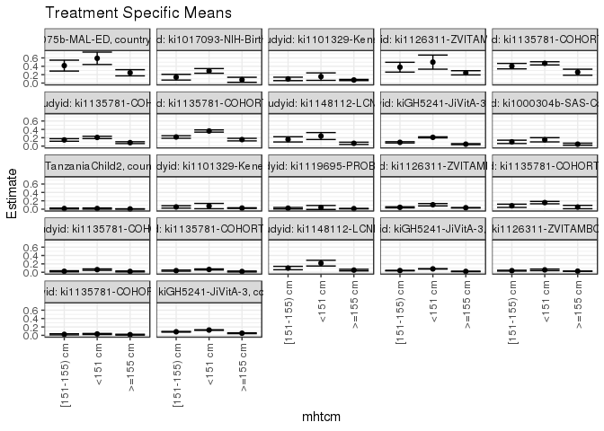

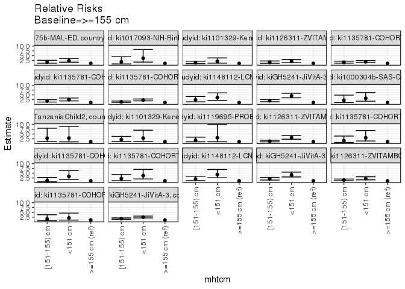

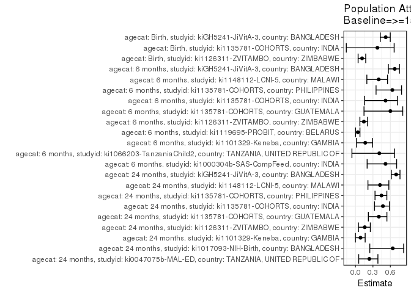

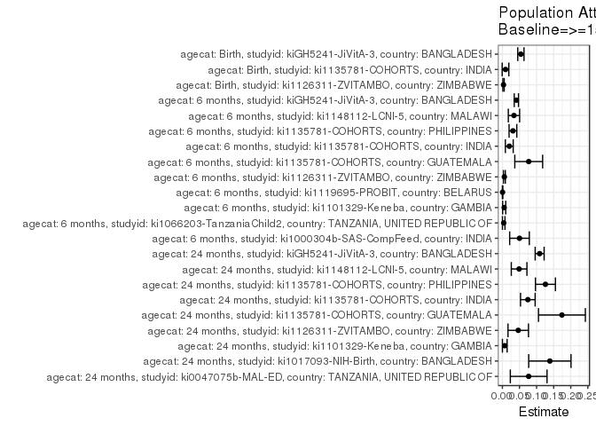

## Results Table

### Parameter: TSM

| agecat | studyid | country | intervention_level | baseline_level | estimate | ci_lower | ci_upper |
| --- | --- | --- | --- | --- | --- | --- | --- |
| Birth | ki1126311-ZVITAMBO | ZIMBABWE | >=155 cm | NA | 0.0259546 | 0.0224057 | 0.0295035 |
| Birth | ki1126311-ZVITAMBO | ZIMBABWE | <151 cm | NA | 0.0566482 | 0.0378571 | 0.0754392 |
| Birth | ki1126311-ZVITAMBO | ZIMBABWE | [151-155) cm | NA | 0.0373712 | 0.0275640 | 0.0471783 |
| Birth | ki1135781-COHORTS | INDIA | >=155 cm | NA | 0.0150943 | 0.0047110 | 0.0254777 |
| Birth | ki1135781-COHORTS | INDIA | <151 cm | NA | 0.0314548 | 0.0190665 | 0.0438431 |
| Birth | ki1135781-COHORTS | INDIA | [151-155) cm | NA | 0.0228690 | 0.0095062 | 0.0362318 |
| Birth | kiGH5241-JiVitA-3 | BANGLADESH | >=155 cm | NA | 0.0499621 | 0.0407221 | 0.0592021 |
| Birth | kiGH5241-JiVitA-3 | BANGLADESH | <151 cm | NA | 0.1256598 | 0.1191948 | 0.1321247 |
| Birth | kiGH5241-JiVitA-3 | BANGLADESH | [151-155) cm | NA | 0.0844241 | 0.0762339 | 0.0926144 |
| 6 months | ki1000304b-SAS-CompFeed | INDIA | >=155 cm | NA | 0.0468349 | 0.0231475 | 0.0705223 |
| 6 months | ki1000304b-SAS-CompFeed | INDIA | <151 cm | NA | 0.1513422 | 0.1010826 | 0.2016018 |
| 6 months | ki1000304b-SAS-CompFeed | INDIA | [151-155) cm | NA | 0.1015994 | 0.0618077 | 0.1413910 |
| 6 months | ki1066203-TanzaniaChild2 | TANZANIA, UNITED REPUBLIC OF | >=155 cm | NA | 0.0056180 | 0.0014669 | 0.0097691 |
| 6 months | ki1066203-TanzaniaChild2 | TANZANIA, UNITED REPUBLIC OF | <151 cm | NA | 0.0161812 | 0.0021097 | 0.0302527 |
| 6 months | ki1066203-TanzaniaChild2 | TANZANIA, UNITED REPUBLIC OF | [151-155) cm | NA | 0.0158730 | 0.0042051 | 0.0275409 |
| 6 months | ki1101329-Keneba | GAMBIA | >=155 cm | NA | 0.0261480 | 0.0182474 | 0.0340485 |
| 6 months | ki1101329-Keneba | GAMBIA | <151 cm | NA | 0.0746269 | 0.0116860 | 0.1375677 |
| 6 months | ki1101329-Keneba | GAMBIA | [151-155) cm | NA | 0.0537190 | 0.0253052 | 0.0821329 |
| 6 months | ki1119695-PROBIT | BELARUS | >=155 cm | NA | 0.0134046 | 0.0088341 | 0.0179751 |
| 6 months | ki1119695-PROBIT | BELARUS | <151 cm | NA | 0.0413223 | -0.0063617 | 0.0890063 |
| 6 months | ki1119695-PROBIT | BELARUS | [151-155) cm | NA | 0.0237467 | 0.0061571 | 0.0413363 |
| 6 months | ki1126311-ZVITAMBO | ZIMBABWE | >=155 cm | NA | 0.0342067 | 0.0294831 | 0.0389303 |
| 6 months | ki1126311-ZVITAMBO | ZIMBABWE | <151 cm | NA | 0.1062038 | 0.0779673 | 0.1344403 |
| 6 months | ki1126311-ZVITAMBO | ZIMBABWE | [151-155) cm | NA | 0.0439542 | 0.0315860 | 0.0563223 |
| 6 months | ki1135781-COHORTS | GUATEMALA | >=155 cm | NA | 0.0512821 | 0.0112934 | 0.0912707 |
| 6 months | ki1135781-COHORTS | GUATEMALA | <151 cm | NA | 0.1573927 | 0.1289181 | 0.1858673 |
| 6 months | ki1135781-COHORTS | GUATEMALA | [151-155) cm | NA | 0.0812183 | 0.0430521 | 0.1193844 |
| 6 months | ki1135781-COHORTS | INDIA | >=155 cm | NA | 0.0188509 | 0.0075020 | 0.0301998 |
| 6 months | ki1135781-COHORTS | INDIA | <151 cm | NA | 0.0624832 | 0.0455216 | 0.0794449 |
| 6 months | ki1135781-COHORTS | INDIA | [151-155) cm | NA | 0.0225541 | 0.0093847 | 0.0357235 |
| 6 months | ki1135781-COHORTS | PHILIPPINES | >=155 cm | NA | 0.0178550 | 0.0072600 | 0.0284500 |
| 6 months | ki1135781-COHORTS | PHILIPPINES | <151 cm | NA | 0.0663821 | 0.0532414 | 0.0795227 |
| 6 months | ki1135781-COHORTS | PHILIPPINES | [151-155) cm | NA | 0.0384883 | 0.0251189 | 0.0518578 |
| 6 months | ki1148112-LCNI-5 | MALAWI | >=155 cm | NA | 0.0510329 | 0.0321080 | 0.0699579 |
| 6 months | ki1148112-LCNI-5 | MALAWI | <151 cm | NA | 0.2168260 | 0.1485903 | 0.2850616 |
| 6 months | ki1148112-LCNI-5 | MALAWI | [151-155) cm | NA | 0.1002830 | 0.0594340 | 0.1411321 |
| 6 months | kiGH5241-JiVitA-3 | BANGLADESH | >=155 cm | NA | 0.0197460 | 0.0138658 | 0.0256262 |
| 6 months | kiGH5241-JiVitA-3 | BANGLADESH | <151 cm | NA | 0.0807970 | 0.0751127 | 0.0864814 |
| 6 months | kiGH5241-JiVitA-3 | BANGLADESH | [151-155) cm | NA | 0.0395956 | 0.0335820 | 0.0456092 |
| 24 months | ki0047075b-MAL-ED | TANZANIA, UNITED REPUBLIC OF | >=155 cm | NA | 0.2455478 | 0.1715154 | 0.3195802 |
| 24 months | ki0047075b-MAL-ED | TANZANIA, UNITED REPUBLIC OF | <151 cm | NA | 0.5912039 | 0.4435120 | 0.7388957 |
| 24 months | ki0047075b-MAL-ED | TANZANIA, UNITED REPUBLIC OF | [151-155) cm | NA | 0.4166811 | 0.2866591 | 0.5467031 |
| 24 months | ki1017093-NIH-Birth | BANGLADESH | >=155 cm | NA | 0.0779221 | 0.0179811 | 0.1378630 |
| 24 months | ki1017093-NIH-Birth | BANGLADESH | <151 cm | NA | 0.2896825 | 0.2336111 | 0.3457540 |
| 24 months | ki1017093-NIH-Birth | BANGLADESH | [151-155) cm | NA | 0.1400000 | 0.0719124 | 0.2080876 |
| 24 months | ki1101329-Keneba | GAMBIA | >=155 cm | NA | 0.0735454 | 0.0595840 | 0.0875069 |
| 24 months | ki1101329-Keneba | GAMBIA | <151 cm | NA | 0.1537020 | 0.0645765 | 0.2428276 |
| 24 months | ki1101329-Keneba | GAMBIA | [151-155) cm | NA | 0.0989940 | 0.0577430 | 0.1402450 |
| 24 months | ki1126311-ZVITAMBO | ZIMBABWE | >=155 cm | NA | 0.2446284 | 0.1940329 | 0.2952239 |
| 24 months | ki1126311-ZVITAMBO | ZIMBABWE | <151 cm | NA | 0.4997509 | 0.3314712 | 0.6680305 |
| 24 months | ki1126311-ZVITAMBO | ZIMBABWE | [151-155) cm | NA | 0.3788101 | 0.2616834 | 0.4959368 |
| 24 months | ki1135781-COHORTS | GUATEMALA | >=155 cm | NA | 0.2591101 | 0.1871642 | 0.3310560 |
| 24 months | ki1135781-COHORTS | GUATEMALA | <151 cm | NA | 0.4711112 | 0.4332250 | 0.5089974 |
| 24 months | ki1135781-COHORTS | GUATEMALA | [151-155) cm | NA | 0.4036608 | 0.3386891 | 0.4686326 |
| 24 months | ki1135781-COHORTS | INDIA | >=155 cm | NA | 0.0833302 | 0.0612098 | 0.1054506 |
| 24 months | ki1135781-COHORTS | INDIA | <151 cm | NA | 0.2075660 | 0.1795889 | 0.2355432 |
| 24 months | ki1135781-COHORTS | INDIA | [151-155) cm | NA | 0.1473854 | 0.1164383 | 0.1783326 |
| 24 months | ki1135781-COHORTS | PHILIPPINES | >=155 cm | NA | 0.1558388 | 0.1251719 | 0.1865056 |
| 24 months | ki1135781-COHORTS | PHILIPPINES | <151 cm | NA | 0.3608181 | 0.3342792 | 0.3873570 |
| 24 months | ki1135781-COHORTS | PHILIPPINES | [151-155) cm | NA | 0.2181698 | 0.1879663 | 0.2483733 |
| 24 months | ki1148112-LCNI-5 | MALAWI | >=155 cm | NA | 0.0671783 | 0.0410935 | 0.0932631 |
| 24 months | ki1148112-LCNI-5 | MALAWI | <151 cm | NA | 0.2407128 | 0.1577100 | 0.3237156 |
| 24 months | ki1148112-LCNI-5 | MALAWI | [151-155) cm | NA | 0.1613084 | 0.0990012 | 0.2236155 |
| 24 months | kiGH5241-JiVitA-3 | BANGLADESH | >=155 cm | NA | 0.0468287 | 0.0349517 | 0.0587057 |
| 24 months | kiGH5241-JiVitA-3 | BANGLADESH | <151 cm | NA | 0.2098558 | 0.1974785 | 0.2222331 |
| 24 months | kiGH5241-JiVitA-3 | BANGLADESH | [151-155) cm | NA | 0.0901441 | 0.0753875 | 0.1049008 |

### Parameter: E(Y)

| agecat | studyid | country | intervention_level | baseline_level | estimate | ci_lower | ci_upper |
| --- | --- | --- | --- | --- | --- | --- | --- |
| Birth | ki1126311-ZVITAMBO | ZIMBABWE | NA | NA | 0.0292749 | 0.0259142 | 0.0326355 |
| Birth | ki1135781-COHORTS | INDIA | NA | NA | 0.0242390 | 0.0170805 | 0.0313975 |
| Birth | kiGH5241-JiVitA-3 | BANGLADESH | NA | NA | 0.1040643 | 0.0993882 | 0.1087404 |
| 6 months | ki1000304b-SAS-CompFeed | INDIA | NA | NA | 0.0969055 | 0.0737418 | 0.1200693 |
| 6 months | ki1066203-TanzaniaChild2 | TANZANIA, UNITED REPUBLIC OF | NA | NA | 0.0095190 | 0.0052582 | 0.0137799 |
| 6 months | ki1101329-Keneba | GAMBIA | NA | NA | 0.0314331 | 0.0235374 | 0.0393288 |
| 6 months | ki1119695-PROBIT | BELARUS | NA | NA | 0.0139646 | 0.0092016 | 0.0187275 |
| 6 months | ki1126311-ZVITAMBO | ZIMBABWE | NA | NA | 0.0399944 | 0.0354446 | 0.0445442 |
| 6 months | ki1135781-COHORTS | GUATEMALA | NA | NA | 0.1283139 | 0.1069569 | 0.1496709 |
| 6 months | ki1135781-COHORTS | INDIA | NA | NA | 0.0390324 | 0.0301298 | 0.0479351 |
| 6 months | ki1135781-COHORTS | PHILIPPINES | NA | NA | 0.0487445 | 0.0406327 | 0.0568562 |
| 6 months | ki1148112-LCNI-5 | MALAWI | NA | NA | 0.0849282 | 0.0660197 | 0.1038368 |
| 6 months | kiGH5241-JiVitA-3 | BANGLADESH | NA | NA | 0.0606685 | 0.0568073 | 0.0645297 |
| 24 months | ki0047075b-MAL-ED | TANZANIA, UNITED REPUBLIC OF | NA | NA | 0.3224299 | 0.2596598 | 0.3852000 |
| 24 months | ki1017093-NIH-Birth | BANGLADESH | NA | NA | 0.2167832 | 0.1777459 | 0.2558205 |
| 24 months | ki1101329-Keneba | GAMBIA | NA | NA | 0.0805243 | 0.0671957 | 0.0938530 |
| 24 months | ki1126311-ZVITAMBO | ZIMBABWE | NA | NA | 0.2910053 | 0.2451542 | 0.3368563 |
| 24 months | ki1135781-COHORTS | GUATEMALA | NA | NA | 0.4332999 | 0.4025255 | 0.4640743 |
| 24 months | ki1135781-COHORTS | INDIA | NA | NA | 0.1577790 | 0.1410223 | 0.1745357 |
| 24 months | ki1135781-COHORTS | PHILIPPINES | NA | NA | 0.2817996 | 0.2639639 | 0.2996353 |
| 24 months | ki1148112-LCNI-5 | MALAWI | NA | NA | 0.1161179 | 0.0899551 | 0.1422806 |
| 24 months | kiGH5241-JiVitA-3 | BANGLADESH | NA | NA | 0.1558275 | 0.1470700 | 0.1645850 |

### Parameter: RR

| agecat | studyid | country | intervention_level | baseline_level | estimate | ci_lower | ci_upper |
| --- | --- | --- | --- | --- | --- | --- | --- |
| Birth | ki1126311-ZVITAMBO | ZIMBABWE | >=155 cm | >=155 cm | 1.000000 | 1.0000000 | 1.000000 |
| Birth | ki1126311-ZVITAMBO | ZIMBABWE | <151 cm | >=155 cm | 2.182584 | 1.5246992 | 3.124336 |
| Birth | ki1126311-ZVITAMBO | ZIMBABWE | [151-155) cm | >=155 cm | 1.439865 | 1.0711606 | 1.935480 |
| Birth | ki1135781-COHORTS | INDIA | >=155 cm | >=155 cm | 1.000000 | 1.0000000 | 1.000000 |
| Birth | ki1135781-COHORTS | INDIA | <151 cm | >=155 cm | 2.083879 | 0.9432426 | 4.603856 |
| Birth | ki1135781-COHORTS | INDIA | [151-155) cm | >=155 cm | 1.515073 | 0.6144022 | 3.736063 |
| Birth | kiGH5241-JiVitA-3 | BANGLADESH | >=155 cm | >=155 cm | 1.000000 | 1.0000000 | 1.000000 |
| Birth | kiGH5241-JiVitA-3 | BANGLADESH | <151 cm | >=155 cm | 2.515102 | 2.0755270 | 3.047774 |
| Birth | kiGH5241-JiVitA-3 | BANGLADESH | [151-155) cm | >=155 cm | 1.689764 | 1.3665833 | 2.089372 |
| 6 months | ki1000304b-SAS-CompFeed | INDIA | >=155 cm | >=155 cm | 1.000000 | 1.0000000 | 1.000000 |
| 6 months | ki1000304b-SAS-CompFeed | INDIA | <151 cm | >=155 cm | 3.231396 | 1.6953965 | 6.158986 |
| 6 months | ki1000304b-SAS-CompFeed | INDIA | [151-155) cm | >=155 cm | 2.169308 | 0.9653664 | 4.874727 |
| 6 months | ki1066203-TanzaniaChild2 | TANZANIA, UNITED REPUBLIC OF | >=155 cm | >=155 cm | 1.000000 | 1.0000000 | 1.000000 |
| 6 months | ki1066203-TanzaniaChild2 | TANZANIA, UNITED REPUBLIC OF | <151 cm | >=155 cm | 2.880259 | 0.9201086 | 9.016209 |
| 6 months | ki1066203-TanzaniaChild2 | TANZANIA, UNITED REPUBLIC OF | [151-155) cm | >=155 cm | 2.825397 | 0.9963933 | 8.011763 |
| 6 months | ki1101329-Keneba | GAMBIA | >=155 cm | >=155 cm | 1.000000 | 1.0000000 | 1.000000 |
| 6 months | ki1101329-Keneba | GAMBIA | <151 cm | >=155 cm | 2.854023 | 1.1651317 | 6.991008 |
| 6 months | ki1101329-Keneba | GAMBIA | [151-155) cm | >=155 cm | 2.054425 | 1.1172215 | 3.777819 |
| 6 months | ki1119695-PROBIT | BELARUS | >=155 cm | >=155 cm | 1.000000 | 1.0000000 | 1.000000 |
| 6 months | ki1119695-PROBIT | BELARUS | <151 cm | >=155 cm | 3.082694 | 0.9585581 | 9.913850 |
| 6 months | ki1119695-PROBIT | BELARUS | [151-155) cm | >=155 cm | 1.771532 | 0.9357442 | 3.353829 |
| 6 months | ki1126311-ZVITAMBO | ZIMBABWE | >=155 cm | >=155 cm | 1.000000 | 1.0000000 | 1.000000 |
| 6 months | ki1126311-ZVITAMBO | ZIMBABWE | <151 cm | >=155 cm | 3.104769 | 2.3012828 | 4.188790 |
| 6 months | ki1126311-ZVITAMBO | ZIMBABWE | [151-155) cm | >=155 cm | 1.284959 | 0.9393920 | 1.757648 |
| 6 months | ki1135781-COHORTS | GUATEMALA | >=155 cm | >=155 cm | 1.000000 | 1.0000000 | 1.000000 |
| 6 months | ki1135781-COHORTS | GUATEMALA | <151 cm | >=155 cm | 3.069157 | 1.3783850 | 6.833887 |
| 6 months | ki1135781-COHORTS | GUATEMALA | [151-155) cm | >=155 cm | 1.583756 | 0.6372270 | 3.936249 |
| 6 months | ki1135781-COHORTS | INDIA | >=155 cm | >=155 cm | 1.000000 | 1.0000000 | 1.000000 |
| 6 months | ki1135781-COHORTS | INDIA | <151 cm | >=155 cm | 3.314606 | 1.7128089 | 6.414385 |
| 6 months | ki1135781-COHORTS | INDIA | [151-155) cm | >=155 cm | 1.196449 | 0.5172648 | 2.767421 |
| 6 months | ki1135781-COHORTS | PHILIPPINES | >=155 cm | >=155 cm | 1.000000 | 1.0000000 | 1.000000 |
| 6 months | ki1135781-COHORTS | PHILIPPINES | <151 cm | >=155 cm | 3.717835 | 1.9895610 | 6.947412 |
| 6 months | ki1135781-COHORTS | PHILIPPINES | [151-155) cm | >=155 cm | 2.155601 | 1.0844326 | 4.284837 |
| 6 months | ki1148112-LCNI-5 | MALAWI | >=155 cm | >=155 cm | 1.000000 | 1.0000000 | 1.000000 |
| 6 months | ki1148112-LCNI-5 | MALAWI | <151 cm | >=155 cm | 4.248745 | 2.6140375 | 6.905728 |
| 6 months | ki1148112-LCNI-5 | MALAWI | [151-155) cm | >=155 cm | 1.965065 | 1.1344114 | 3.403950 |
| 6 months | kiGH5241-JiVitA-3 | BANGLADESH | >=155 cm | >=155 cm | 1.000000 | 1.0000000 | 1.000000 |
| 6 months | kiGH5241-JiVitA-3 | BANGLADESH | <151 cm | >=155 cm | 4.091814 | 3.0204755 | 5.543149 |
| 6 months | kiGH5241-JiVitA-3 | BANGLADESH | [151-155) cm | >=155 cm | 2.005245 | 1.4232597 | 2.825211 |
| 24 months | ki0047075b-MAL-ED | TANZANIA, UNITED REPUBLIC OF | >=155 cm | >=155 cm | 1.000000 | 1.0000000 | 1.000000 |
| 24 months | ki0047075b-MAL-ED | TANZANIA, UNITED REPUBLIC OF | <151 cm | >=155 cm | 2.407694 | 1.6323916 | 3.551225 |
| 24 months | ki0047075b-MAL-ED | TANZANIA, UNITED REPUBLIC OF | [151-155) cm | >=155 cm | 1.696945 | 1.1005295 | 2.616579 |
| 24 months | ki1017093-NIH-Birth | BANGLADESH | >=155 cm | >=155 cm | 1.000000 | 1.0000000 | 1.000000 |
| 24 months | ki1017093-NIH-Birth | BANGLADESH | <151 cm | >=155 cm | 3.717593 | 1.6817843 | 8.217757 |
| 24 months | ki1017093-NIH-Birth | BANGLADESH | [151-155) cm | >=155 cm | 1.796667 | 0.7231383 | 4.463892 |
| 24 months | ki1101329-Keneba | GAMBIA | >=155 cm | >=155 cm | 1.000000 | 1.0000000 | 1.000000 |
| 24 months | ki1101329-Keneba | GAMBIA | <151 cm | >=155 cm | 2.089892 | 1.1354343 | 3.846677 |
| 24 months | ki1101329-Keneba | GAMBIA | [151-155) cm | >=155 cm | 1.346025 | 0.8515239 | 2.127695 |
| 24 months | ki1126311-ZVITAMBO | ZIMBABWE | >=155 cm | >=155 cm | 1.000000 | 1.0000000 | 1.000000 |
| 24 months | ki1126311-ZVITAMBO | ZIMBABWE | <151 cm | >=155 cm | 2.042898 | 1.3760045 | 3.033008 |
| 24 months | ki1126311-ZVITAMBO | ZIMBABWE | [151-155) cm | >=155 cm | 1.548513 | 1.0674955 | 2.246278 |
| 24 months | ki1135781-COHORTS | GUATEMALA | >=155 cm | >=155 cm | 1.000000 | 1.0000000 | 1.000000 |
| 24 months | ki1135781-COHORTS | GUATEMALA | <151 cm | >=155 cm | 1.818189 | 1.3630577 | 2.425292 |
| 24 months | ki1135781-COHORTS | GUATEMALA | [151-155) cm | >=155 cm | 1.557874 | 1.1319203 | 2.144119 |
| 24 months | ki1135781-COHORTS | INDIA | >=155 cm | >=155 cm | 1.000000 | 1.0000000 | 1.000000 |
| 24 months | ki1135781-COHORTS | INDIA | <151 cm | >=155 cm | 2.490886 | 1.8523941 | 3.349457 |
| 24 months | ki1135781-COHORTS | INDIA | [151-155) cm | >=155 cm | 1.768692 | 1.2629050 | 2.477043 |
| 24 months | ki1135781-COHORTS | PHILIPPINES | >=155 cm | >=155 cm | 1.000000 | 1.0000000 | 1.000000 |
| 24 months | ki1135781-COHORTS | PHILIPPINES | <151 cm | >=155 cm | 2.315330 | 1.8770493 | 2.855946 |
| 24 months | ki1135781-COHORTS | PHILIPPINES | [151-155) cm | >=155 cm | 1.399971 | 1.1007803 | 1.780482 |
| 24 months | ki1148112-LCNI-5 | MALAWI | >=155 cm | >=155 cm | 1.000000 | 1.0000000 | 1.000000 |
| 24 months | ki1148112-LCNI-5 | MALAWI | <151 cm | >=155 cm | 3.583191 | 2.1336133 | 6.017611 |
| 24 months | ki1148112-LCNI-5 | MALAWI | [151-155) cm | >=155 cm | 2.401197 | 1.3887198 | 4.151842 |
| 24 months | kiGH5241-JiVitA-3 | BANGLADESH | >=155 cm | >=155 cm | 1.000000 | 1.0000000 | 1.000000 |
| 24 months | kiGH5241-JiVitA-3 | BANGLADESH | <151 cm | >=155 cm | 4.481348 | 3.4569815 | 5.809254 |
| 24 months | kiGH5241-JiVitA-3 | BANGLADESH | [151-155) cm | >=155 cm | 1.924975 | 1.4176502 | 2.613853 |

### Parameter: PAR

| agecat | studyid | country | intervention_level | baseline_level | estimate | ci_lower | ci_upper |
| --- | --- | --- | --- | --- | --- | --- | --- |
| Birth | ki1126311-ZVITAMBO | ZIMBABWE | >=155 cm | NA | 0.0033202 | 0.0013714 | 0.0052691 |
| Birth | ki1135781-COHORTS | INDIA | >=155 cm | NA | 0.0091447 | -0.0005835 | 0.0188728 |
| Birth | kiGH5241-JiVitA-3 | BANGLADESH | >=155 cm | NA | 0.0541022 | 0.0449393 | 0.0632651 |
| 6 months | ki1000304b-SAS-CompFeed | INDIA | >=155 cm | NA | 0.0500706 | 0.0213027 | 0.0788385 |
| 6 months | ki1066203-TanzaniaChild2 | TANZANIA, UNITED REPUBLIC OF | >=155 cm | NA | 0.0039011 | 0.0001764 | 0.0076257 |
| 6 months | ki1101329-Keneba | GAMBIA | >=155 cm | NA | 0.0052852 | 0.0007603 | 0.0098101 |
| 6 months | ki1119695-PROBIT | BELARUS | >=155 cm | NA | 0.0005599 | -0.0000136 | 0.0011335 |
| 6 months | ki1126311-ZVITAMBO | ZIMBABWE | >=155 cm | NA | 0.0057877 | 0.0030633 | 0.0085122 |
| 6 months | ki1135781-COHORTS | GUATEMALA | >=155 cm | NA | 0.0770318 | 0.0363083 | 0.1177554 |
| 6 months | ki1135781-COHORTS | INDIA | >=155 cm | NA | 0.0201816 | 0.0087242 | 0.0316389 |
| 6 months | ki1135781-COHORTS | PHILIPPINES | >=155 cm | NA | 0.0308894 | 0.0195819 | 0.0421970 |
| 6 months | ki1148112-LCNI-5 | MALAWI | >=155 cm | NA | 0.0338953 | 0.0173658 | 0.0504248 |
| 6 months | kiGH5241-JiVitA-3 | BANGLADESH | >=155 cm | NA | 0.0409225 | 0.0347231 | 0.0471219 |
| 24 months | ki0047075b-MAL-ED | TANZANIA, UNITED REPUBLIC OF | >=155 cm | NA | 0.0768821 | 0.0231966 | 0.1305677 |
| 24 months | ki1017093-NIH-Birth | BANGLADESH | >=155 cm | NA | 0.1388611 | 0.0769979 | 0.2007244 |
| 24 months | ki1101329-Keneba | GAMBIA | >=155 cm | NA | 0.0069789 | 0.0001281 | 0.0138297 |
| 24 months | ki1126311-ZVITAMBO | ZIMBABWE | >=155 cm | NA | 0.0463769 | 0.0164341 | 0.0763197 |
| 24 months | ki1135781-COHORTS | GUATEMALA | >=155 cm | NA | 0.1741898 | 0.1056407 | 0.2427390 |
| 24 months | ki1135781-COHORTS | INDIA | >=155 cm | NA | 0.0744488 | 0.0530691 | 0.0958286 |
| 24 months | ki1135781-COHORTS | PHILIPPINES | >=155 cm | NA | 0.1259608 | 0.0967575 | 0.1551641 |
| 24 months | ki1148112-LCNI-5 | MALAWI | >=155 cm | NA | 0.0489395 | 0.0260661 | 0.0718130 |
| 24 months | kiGH5241-JiVitA-3 | BANGLADESH | >=155 cm | NA | 0.1089988 | 0.0959171 | 0.1220805 |

### Parameter: PAF

| agecat | studyid | country | intervention_level | baseline_level | estimate | ci_lower | ci_upper |
| --- | --- | --- | --- | --- | --- | --- | --- |
| Birth | ki1126311-ZVITAMBO | ZIMBABWE | >=155 cm | NA | 0.1134154 | 0.0455959 | 0.1764157 |
| Birth | ki1135781-COHORTS | INDIA | >=155 cm | NA | 0.3772707 | -0.1575587 | 0.6649917 |
| Birth | kiGH5241-JiVitA-3 | BANGLADESH | >=155 cm | NA | 0.5198920 | 0.4262593 | 0.5982442 |
| 6 months | ki1000304b-SAS-CompFeed | INDIA | >=155 cm | NA | 0.5166951 | 0.2004357 | 0.7078614 |
| 6 months | ki1066203-TanzaniaChild2 | TANZANIA, UNITED REPUBLIC OF | >=155 cm | NA | 0.4098167 | -0.0610110 | 0.6717128 |
| 6 months | ki1101329-Keneba | GAMBIA | >=155 cm | NA | 0.1681403 | 0.0180716 | 0.2952740 |
| 6 months | ki1119695-PROBIT | BELARUS | >=155 cm | NA | 0.0400972 | 0.0014302 | 0.0772670 |
| 6 months | ki1126311-ZVITAMBO | ZIMBABWE | >=155 cm | NA | 0.1447134 | 0.0758568 | 0.2084395 |
| 6 months | ki1135781-COHORTS | GUATEMALA | >=155 cm | NA | 0.6003391 | 0.1466206 | 0.8128278 |
| 6 months | ki1135781-COHORTS | INDIA | >=155 cm | NA | 0.5170459 | 0.1571400 | 0.7232700 |
| 6 months | ki1135781-COHORTS | PHILIPPINES | >=155 cm | NA | 0.6337013 | 0.3538594 | 0.7923444 |
| 6 months | ki1148112-LCNI-5 | MALAWI | >=155 cm | NA | 0.3991050 | 0.1957005 | 0.5510693 |
| 6 months | kiGH5241-JiVitA-3 | BANGLADESH | >=155 cm | NA | 0.6745262 | 0.5654749 | 0.7562093 |
| 24 months | ki0047075b-MAL-ED | TANZANIA, UNITED REPUBLIC OF | >=155 cm | NA | 0.2384460 | 0.0558067 | 0.3857567 |
| 24 months | ki1017093-NIH-Birth | BANGLADESH | >=155 cm | NA | 0.6405530 | 0.2465165 | 0.8285269 |
| 24 months | ki1101329-Keneba | GAMBIA | >=155 cm | NA | 0.0866682 | -0.0012597 | 0.1668746 |
| 24 months | ki1126311-ZVITAMBO | ZIMBABWE | >=155 cm | NA | 0.1593680 | 0.0509902 | 0.2553689 |
| 24 months | ki1135781-COHORTS | GUATEMALA | >=155 cm | NA | 0.4020076 | 0.2216909 | 0.5405490 |
| 24 months | ki1135781-COHORTS | INDIA | >=155 cm | NA | 0.4718550 | 0.3281229 | 0.5848390 |
| 24 months | ki1135781-COHORTS | PHILIPPINES | >=155 cm | NA | 0.4469873 | 0.3359299 | 0.5394717 |
| 24 months | ki1148112-LCNI-5 | MALAWI | >=155 cm | NA | 0.4214642 | 0.2143630 | 0.5739716 |
| 24 months | kiGH5241-JiVitA-3 | BANGLADESH | >=155 cm | NA | 0.6994836 | 0.6152183 | 0.7652953 |